# simon-5502-06-demo

# — Part 1

## File details

This program was written by Steve Simon on 2025-02-23 and is placed in the public domain. You can use this program any way you please.

There are two data files used in this program

- marriage, [Tab delimited file](https://github.com/pmean/data/blob/main/files/marriage-age-2015.txt), [dictionary](https://github.com/pmean/data/blob/main/files/marriage-age-2015.yaml)
- titanic, [Tab delimited file](https://github.com/pmean/data/blob/main/files/titanic.txt), [dictionary](https://github.com/pmean/data/blob/main/files/titanic.yaml)

## Intermediate files

- titanic.txt
  - titanic0: Original data
  - titanic1: Create factor for survived
  - titanic2: Remove missing values for age
  - titanic3: Combine into 20 age groups
- marriage.tsv
  - marriage0: Original data

```r
library(broom)
library(glue)
library(splines)
library(tidyverse)

R.version.string
```

```
[1] "R version 4.5.0 (2025-04-11 ucrt)"
```

```r
Sys.Date()
```

```
[1] "2026-02-24"
```

```r
marriage0 <- read_tsv(
  file="https://dasl.datadescription.com/download/data/3329",
  col_names=TRUE,
  col_types="n")
names(marriage0) <- tolower(names(marriage0))
glimpse(marriage0)
```

```
Rows: 75
Columns: 3
$ year  <dbl> 1890, 1900, 1910, 1920, 1930, 1940, 1947, 1948, 1949, 1950, 1951…
$ men   <dbl> 26.1, 25.9, 25.1, 24.6, 24.3, 24.3, 23.7, 23.3, 22.7, 22.8, 22.9…
$ women <dbl> 22.0, 21.9, 21.6, 21.2, 21.3, 21.5, 20.5, 20.4, 20.3, 20.3, 20.4…
```

## Descriptive statistics for year

```r
marriage0 |>
  summarize(
    year_min=min(year),
    year_max=max(year)) -> marriage_year_descriptives

marriage_year_descriptives
```

```
# A tibble: 1 × 2
  year_min year_max
     <dbl>    <dbl>
1     1890     2015
```

#### Comment on the code

For a variable as simple and straight forward as year, the minimum and maximum values provide a good enough summary.

#### Interpretation of the output

The data was collected starting in 1890 and ending in 2015.

## Descriptive statistics for men

```r
marriage0 |>
  summarize(
    men_mean=mean(men),
    men_sd=sd(men),
    men_min=min(men),
    men_max=max(men)) -> marriage_men_descriptives

marriage_men_descriptives
```

```
# A tibble: 1 × 4
  men_mean men_sd men_min men_max
     <dbl>  <dbl>   <dbl>   <dbl>
1     25.1   2.11    22.5    29.7
```

#### Interpretation of the output

The average age for marriage across all the years is a bit more than 25 years. The range is narrow, to be expected for an average, though it has been as almost as low as 22 years and as high as 30 years.

## Trend for men

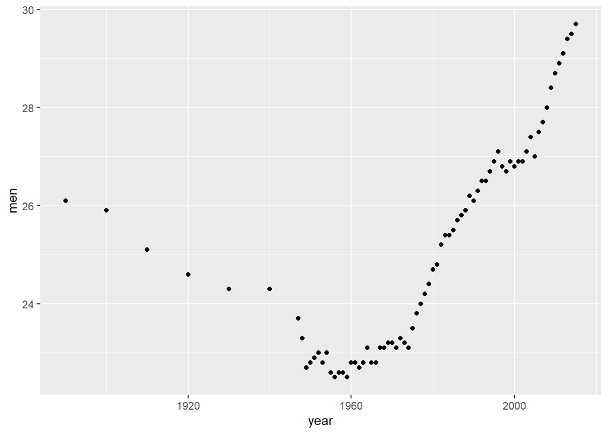

```r
marriage0 |>
  ggplot() +
  aes(x=year, y=men) +
  geom_point() -> marriage_men_trend1

marriage_men_trend1
```

#### Interpretation of the output

The average age declines through the 1960s the rebounds to an even higher average through 2015.

## Linear model and spline models for men

```r
library(splines)

marriage_men_linear <- lm(men ~ year, data=marriage0)
marriage_men_spline <- lm(men ~ year+bs(year, df=5), data=marriage0)

anova(marriage_men_linear,marriage_men_spline) |>
  tidy() |>
  data.frame() |>
  mutate(
    p.value =
      case_when(
        p.value >= 0.001 ~ glue("p = {round(p.value, 3)}"),
        p.value <  0.001 ~ "p < 0.001")) -> marriage_men_anova

marriage_men_anova
```

```
                           term df.residual        rss df    sumsq statistic
1                    men ~ year          73 180.909840 NA       NA        NA
2 men ~ year + bs(year, df = 5)          69   6.814632  4 174.0952  440.6903
    p.value
1      <NA>
2 p < 0.001
```

#### Comments on the code

The [bs function](https://stat.ethz.ch/R-manual/R-devel/library/splines/html/bs.html) is part of the [splines library](https://stat.ethz.ch/R-manual/R-devel/library/splines/html/00Index.html).

This analysis of variance table does not display well as a tibble. The [data.frame function](https://stat.ethz.ch/R-manual/R-devel/library/base/html/data.frame.html), part of the base R package, converts various objects (including tibbles) into data frames. The data frame comes with base R and were there from the very start. The tibble was introduced about the same time as tidyverse was being deployed. There are [small but important differences](https://jtr13.github.io/cc21fall1/tibble-vs.-dataframe.html) between tibbles and data frames, but for most applications they are largely interchangeable. Most of the output from tidyverse functions are tibbles even if the input is a data frame.

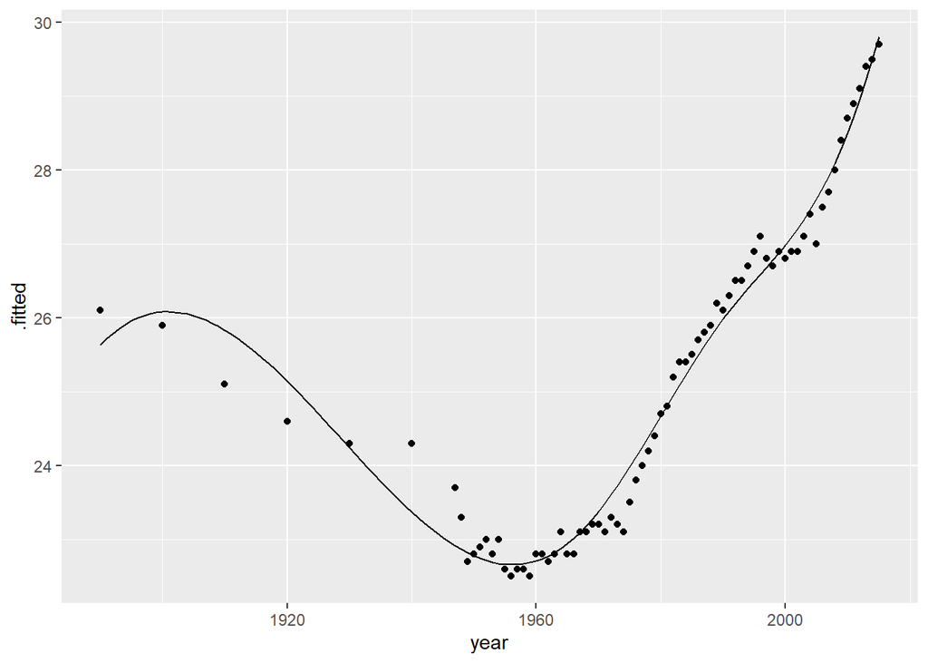

```r
marriage_men_spline |>
  augment(newdata=tibble(year=1890:2015)) |>
  ggplot() +
  aes(x=year, y=.fitted) +
  geom_line() +
  geom_point(data=marriage0, aes(x=year, y=men))
```

#### Comments on the code

The [augment function](https://broom.tidymodels.org/reference/augment.lm.html) will default to produce predictions (as well as residuals and influence diangostics) at the values of the independent variables in the observed dataset. You can produce predictions values at new values with the newdata argument. When you supply new data, measures like leverage, studentized residuals, and Cook’s distance can no longer be computed.

The augmented dataset will not include values of the original outcome variable, so you need to specify data=marriage0 in the [geom_point function](https://ggplot2.tidyverse.org/reference/geom_point.html) to get those values plotted.

#### Interpretation of the output

The spline does a reasonable job of prediction, except for the 19030s and 1940s. This was a time that saw the Great Depression and World War II, and both probably had an unusual impact on marriage ages. You might consider adding one or two extra knots or defining the location of the knots directly, but most of my experiments with this did not lead to better predictions in the 1930s and 1940s.

# — Part 2

## Read Titanic data

```r
titanic0 <- read_tsv(
  file="../data/titanic.txt",
  col_names=TRUE,
  col_types="ccncn",
  na="NA")

names(titanic0) <- tolower(names(titanic0))

glimpse(titanic0)
```

```
Rows: 1,313
Columns: 5
$ name     <chr> "Allen, Miss Elisabeth Walton", "Allison, Miss Helen Loraine"…
$ pclass   <chr> "1st", "1st", "1st", "1st", "1st", "1st", "1st", "1st", "1st"…
$ age      <dbl> 29.00, 2.00, 30.00, 25.00, 0.92, 47.00, 63.00, 39.00, 58.00, …
$ sex      <chr> "female", "female", "male", "female", "male", "male", "female…
$ survived <dbl> 1, 0, 0, 0, 1, 1, 1, 0, 1, 0, 0, 1, 1, 1, 0, 1, 0, 0, 1, 1, 1…
```

## Add factors

```r
lab1 <- c("Died", "Survived")
lab2 <- c("3rd", "2nd", "1st")

titanic0 |>
  mutate(
    survived =
      factor(
            survived,
            levels=1:0,
            labels=c("Yes", "No"))) |>
  mutate(
    pclass =
      factor(
        pclass,
        levels=lab2))-> titanic1
```

## Remove missing ages

```r
titanic1 |>
    filter(!is.na(age)) -> titanic2
```

## Descriptive statistics for survived

```r
titanic2 |>
  count(survived) |>
  mutate(total=sum(n)) |>
  mutate(pct=round(100*n/total)) |>
  mutate(pct=glue("{pct}% ({n}/{total})")) |>
  select(-n, -total) -> titanic_survived_descriptives

titanic_survived_descriptives
```

```
# A tibble: 2 × 2
  survived pct
  <fct>    <glue>
1 Yes      41% (313/756)
2 No       59% (443/756)
```

#### Interpretation of the output

Almost 60% of the passengers on the Titanic died.

```r
titanic2 |>
    summarize(
        age_mean=mean(age),
        age_sd=sd(age),
        age_min=min(age),
        age_max=max(age)) -> titanic_age_descriptives

titanic_age_descriptives
```

```
# A tibble: 1 × 4
  age_mean age_sd age_min age_max
     <dbl>  <dbl>   <dbl>   <dbl>
1     30.4   14.3    0.17      71
```

#### Interpretation of the output

The average passenger is 30 years old. The age range is very wide, from less than one year old to 71 years old.

## Check for linearity

```r
titanic2 |>
  mutate(age_group=ntile(x=age, n=20)) |>
  group_by(age_group) |>
  summarize(
    age_mean=mean(age),
    mortality_probability=mean(survived=="No")) |>
  arrange(age_mean)  -> titanic3

titanic3
```

```
# A tibble: 20 × 3
   age_group age_mean mortality_probability
       <int>    <dbl>                 <dbl>
 1         1     2.60                 0.211
 2         2    11.3                  0.5
 3         3    17.3                  0.526
 4         4    18.8                  0.579
 5         5    20.5                  0.711
 6         6    21.7                  0.632
 7         7    22.9                  0.632
 8         8    24.4                  0.658
 9         9    25.9                  0.658
10        10    27.5                  0.658
11        11    29.3                  0.789
12        12    30.9                  0.553
13        13    33                    0.605
14        14    35.6                  0.421
15        15    38.0                  0.658
16        16    41.3                  0.711
17        17    45.1                  0.568
18        18    48.4                  0.514
19        19    53.5                  0.514
20        20    62.5                  0.622
```

#### Comments on the code

The [ntile function](https://dplyr.tidyverse.org/reference/ranking.html) is part of the dplyr/tidyverse libraries. It divides the data into groups of roughly equal size. The n argumet specifies the number of groups.

The average of a logical statement, such as survived==“No” converts the true values to one and the false values to zero. The average is then equivalent to the probability that the logical statement is true. In this case, it represents the mortality probability.

#### Interpretation of the output

The selection of the number of groups is somewhat arbitrary, and you may prefer to use a smaller number of groups. The mortality probabilities seem to rise with age until about 20 then level off. The data is a bit noisy, and larger groups might show a bit more stability, though at the expense of losing information about the trends in the children.

## Plot of age trends

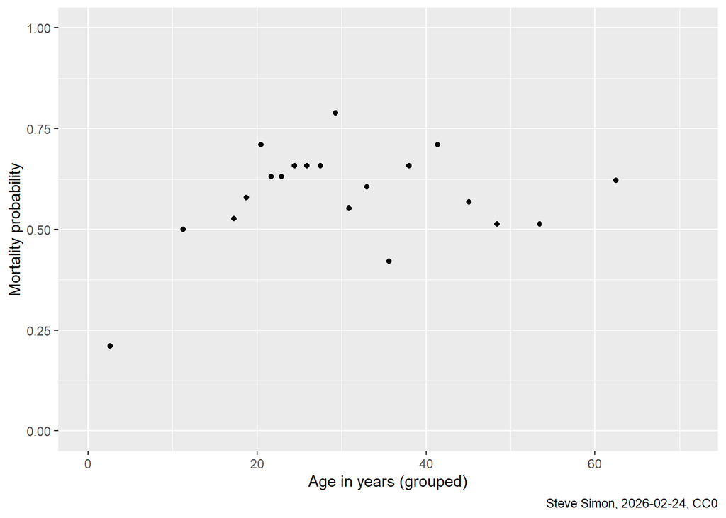

```r
titanic3 |>
  ggplot() +
    aes(x=age_mean, y=mortality_probability) +
    geom_point() +
  labs(
    x="Age in years (grouped)",
    y="Mortality probability",
    caption="Steve Simon, 2026-02-24, CC0") +
  scale_x_continuous(limits=c(0,71)) +
  scale_y_continuous(limits=0:1) -> titanic_age_trend1

titanic_age_trend1
```

#### Interpretation of the output

The plot provides a similar interpretation as the table.

## Logistic regression using age to predict survived

```r
titanic_age_linear <- glm(
    survived ~ age,
    family=binomial,
    data=titanic2)

titanic_age_spline <- glm(
    survived ~ age+bs(age, df=5),
    family=binomial,
    data=titanic2)

anova(
  titanic_age_linear,
  titanic_age_spline) |>
  tidy() |>
  mutate(
    p.value =
      case_when(
        p.value >= 0.001 ~ glue("p = {round(p.value, 3)}"),
        p.value <  0.001 ~ "p < 0.001")) -> titanic_age_spline_anova

titanic_age_spline_anova |> data.frame()
```

```
                              term df.residual residual.deviance df deviance
1                   survived ~ age         754         1022.7232 NA       NA
2 survived ~ age + bs(age, df = 5)         750          996.8301  4 25.89313
    p.value
1      <NA>
2 p < 0.001
```

#### Interpretation of the output

The residual.deviance and deviance columns are somewhat analogous to unexplained and explained variation, but the formulas are a bit more complex. The deviance has a chi-squared distribution. A value close to the degrees of freedom indicates that you should accept the null hypothesis that the second model does not provide significantly better predictions than the first model. In this case the test statistic is a lot larger than the degrees of freedom and the p-value is small, so you should reject the null hypothesis and conclude that the spline model provides a better prediction of mortality than a linear model.

## Predicted values for linear and spline fits

```r
titanic_age_linear |>
  augment(
    newdata=tibble(age=seq(1, 71, 1)),
    type.predict="response") -> titanic_age_linear_predictions

titanic_age_spline |>
  augment(
    newdata=tibble(age=seq(1, 71, 1)),
    type.predict="response") -> titanic_age_spline_predictions
```

#### Comments on the code

Recall that the logistic regression model is linear on a log odds scale. When you use the augment function to produce [predictions for the output from glm](https://broom.tidymodels.org/reference/augment.glm.html), you can get predictions on the log odds scale with the argument type.predict=“link”. It is easier to interpret the predictions on the probability scale, and you get this with the argument type.predict=“response”.

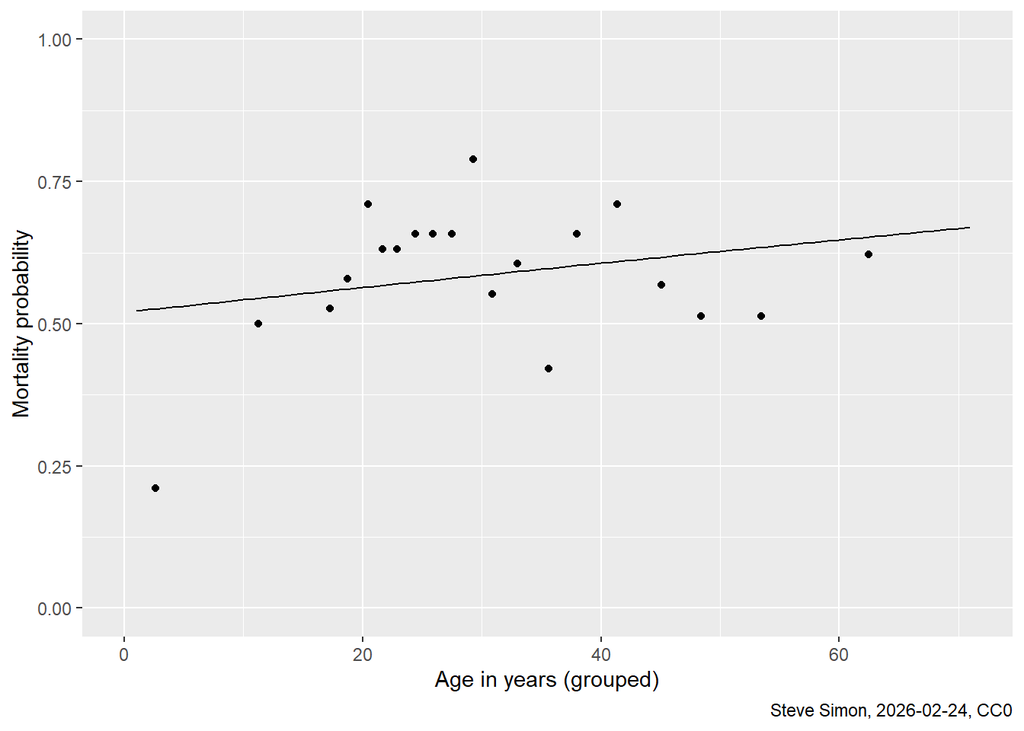

```r
titanic_age_trend1 +
  geom_line(
    data=titanic_age_linear_predictions,
    aes(x=age, y=.fitted)) -> titanic_age_trend2

titanic_age_trend2
```

#### Interpretation of the output

The linear trend seems to overestimate the mortality probabilities for the very young passengers.

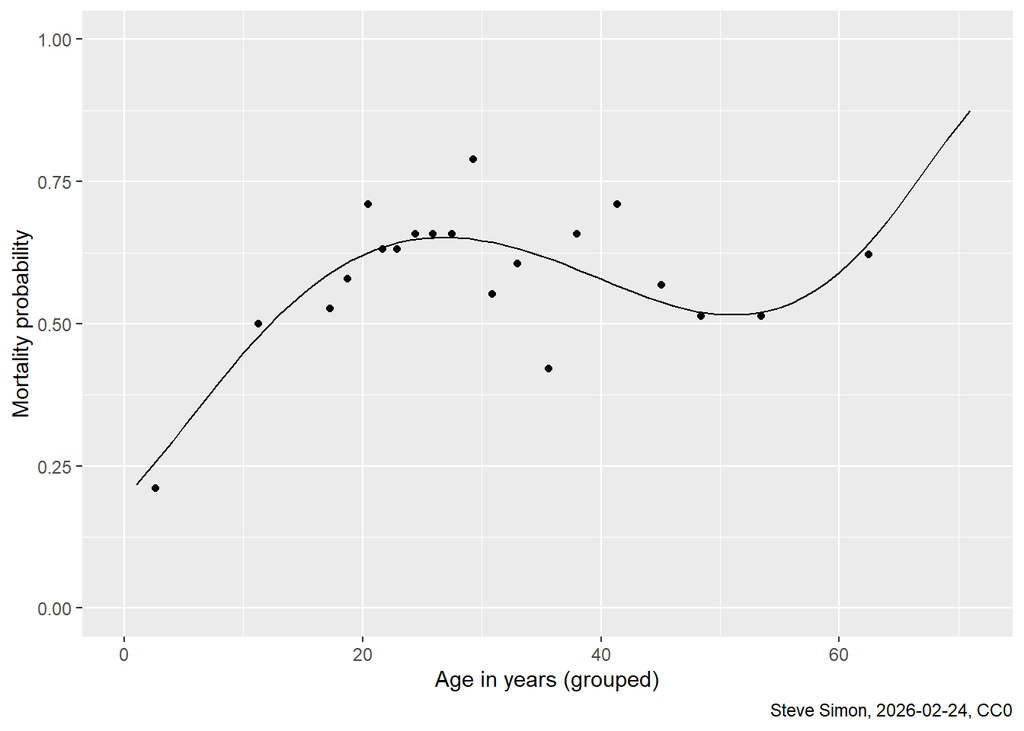

```r
titanic_age_trend1 +
  geom_line(
    data=titanic_age_spline_predictions,
    aes(x=age, y=.fitted)) -> titanic_age_trend3

titanic_age_trend3
```

#### Interpretation of the output

The spline seems to do a better job of predicting mortality probabilities for the very young passengers. It also seems to indicatean increase in mortality probability for passengers 55 and above, though this may not be supported by the actual data.

## Save everything

```r
save.image(file="../data/module06.RData")
```